# Inwestycje Alternatywne Projekt

Julia Sulka 189564, Julia Urban 202289, Basia 206744, Jakub Pilarski 184815

2025-01-30

# 1 Wstęp

# 2 Charakterystyka inwestycji

## 2.1 MCI Capital ASI SA - fundusz inwestycyjny

Jest polska Alternatywna Spółka Inwestycyjna (ASI), czyli fundusz, który oferuje inwestorom alternatywne opcje inwestycyjne, które charakteryzują się wyższym ryzykiem, ale mogą przynieść atrakcyjniejsze zwroty, które nie są dostępne w ramach tradycyjnych funduszy inwestycyjnych. Specjalizuje się w inwestycjach związanych z cyfrową transformacją gospodarki oraz innowacyjnymi modelami biznesowymi. Aktualne portfolio funduszu obejmuje 14 aktywnych inwestycji w takich obszarach jak e-commerce, fintech, SaaS, cloud gaming, rynki internetowe oraz technologie związane z zieloną transformacją i klimatem (climatech). Fundusz koncentruje się na wspieraniu firm, które wprowadzają innowacyjne rozwiązania w swoich branżach, a także na wspieraniu rozwoju infrastruktury internetowej.

## 2.2 PKN ORLEN SA

PKN ORLEN SA to polski koncern multienergetyczny, który działa w sektorze naftowym, gazowym, petrochemicznym oraz energii odnawialnej. Jest jednym z największych przedsiębiorstw w Europie Środkowo-Wschodniej, notowanym na Giełdzie Papierów Wartościowych w Warszawie. PKN ORLEN posiada rozwiniętą sieć stacji paliwowych w Polsce oraz w regionie Europy Środkowo-Wschodniej, oferując szeroką gamę produktów i usług, w tym programy lojalnościowe oraz rozwiązania z zakresu elektromobilności. Portfolio spółki obejmuje również zaawansowane technologie petrochemiczne oraz produkty chemiczne, które znajdują zastosowanie w wielu branżach przemysłowych. ORLEN jest liderem w branży energetycznej w Polsce, a jego strategiczne inwestycje przyczyniają się do zwiększenia bezpieczeństwa energetycznego kraju oraz wsparcia transformacji w kierunku gospodarki niskoemisyjnej.

## 2.3 ZŁOTO

Złoto to metal szlachetny o symbolu chemicznym Au i numerze atomowym 79. Jest jednym z najbardziej cenionych surowców na świecie, znanym ze swojej trwałości, odporności na korozję i wyjątkowego, żółtego koloru. Złoto występuje w naturze w postaci czystych bryłek (złoto rodzimne) lub w postaci związków z innymi pierwiastkami. Wykorzystywane jest głównie w jubilerstwie, ale ma także szerokie zastosowanie w elektronice, medycynie, przemyśle i finansach. Złoto jest uważane za bezpieczną inwestycję w okresach kryzysów gospodarczych.

## 2.4 EURO

EURO (EUR) Euro to waluta używana w 20 krajach członkowskich Unii Europejskiej, która jest jedną z najważniejszych walut rezerwowych na świecie. Jako waluta wspólna dla strefy euro, Euro jest stabilnym elementem globalnego systemu finansowego. Jego znaczenie wynika nie tylko z wielkości strefy euro, ale także z roli, jaką pełni w międzynarodowych transakcjach finansowych i handlowych. Jest uważane za stabilne medium wymiany, a jego kurs jest monitorowany przez Europejski Bank Centralny (EBC), który kontroluje podaż pieniądza w regionie oraz wpływa na jego wartość poprzez politykę monetarną. W portfelu inwestycyjnym, Euro pełni rolę elementu stabilizującego, chroniąc przed ryzykiem związanym z innymi, bardziej zmiennymi walutami. Ponadto, euro jest atrakcyjne w kontekście inwestycji zagranicznych, zapewniając ekspozycję na rozwinięte gospodarki strefy euro, takie jak Niemcy, Francja czy Holandia. W czasach globalnych zawirowań ekonomicznych, Euro może również pełnić rolę bezpiecznej przystani, podobnie jak złoto.

# 3 Statystyki opisowe

Przy wykonywaniu statystyk opisowych dla stóp zwrotu wybór między zmianą procentową a logarytmiczną stopą zwrotu zależy od celu analizy oraz właściwości danych. Oba wskaźniki mają swoje zalety i są stosowane w różnych kontekstach.

Dla danych finansowych, analizowanych w tym rozdziale, zastosowane procentową stopę zwrotu, ponieważ daje ona łatwość interpretacji oraz pozwala na porównanie między różnymi aktywami. Procentowa stopa zwrotu jest wyrażana jako procentowa zmiana wartości aktywa w określonym okresie. Jest to wskaźnik, który informuje o wzroście lub spadku wartości aktywa w danym okresie.

## 3.1 Wykresy cen wybranych aktywów

Na poniższych wykresach zaobserować można procentowe zmiany ceny poszczególnych aktywów na przestrzeni okresu około 4 miesięcy.

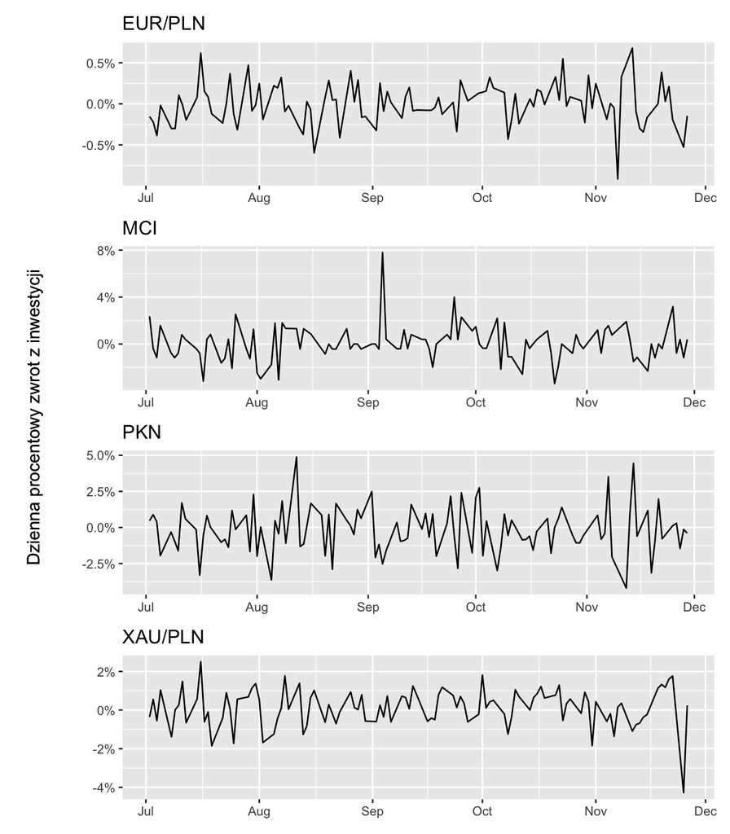

## 3.2 Wykresy pudełkowe

Poniższe wykresy pudełkowe przedstawiają rozkład zmiennych, ukazując ich centralną tendencję, rozproszenie oraz obecność wartości odstających. Na wykresie widać kilka kluczowych elementów opisanych poniżej. Dla łatwiejszej interpretacji wykresy zostały jednolicie wyskalowane aby ułatwić porównanie między aktywami.

Wykres pudełkowy dostarcza wizualnych informacji o rozkładzie zmiennej, umożliwiając identyfikację jej średniej, zakresu, rozproszenia oraz wartości odstających, a także ocenę symetrii lub asymetrii danych.

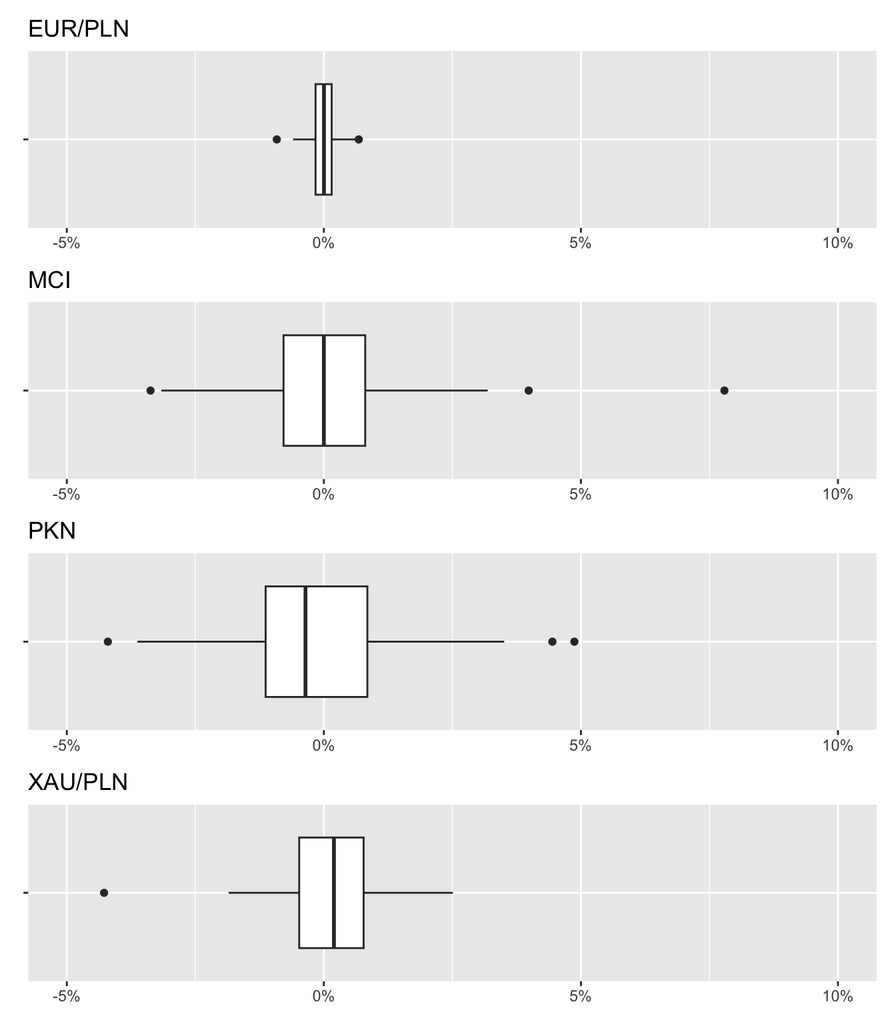

## 3.3 Statystyki opisowe

Tabela przedstawia statystyki opisowe dla czterech zmiennych: EUR/PLN (cena euro w złotówkach), MCI (MCI Capital ASI SA, polska Alternatywna Spółka Inwestycyjna), PKN (spółka PKN Orlen) oraz XAU/PLN (cena uncji złota w polskich złotych). Każda z tych zmiennych reprezentuje istotny składnik portfela inwestycyjnego, a ich analiza pozwala ocenić stabilność oraz zmienność poszczególnych aktywów.

|  | EUR/PLN | MCI | PKN | XAU/PLN |
| --- | --- | --- | --- | --- |
| Średnia arytmetyczna (%) | -0.002 | 0.019 | -0.190 | 0.139 |
| Odchylenie standardowe (%) | 0.256 | 1.553 | 1.620 | 0.972 |
| Mediana (%) | 0.002 | 0.000 | -0.358 | 0.196 |
| Przycięta średnia (%) | 0.000 | -0.020 | -0.226 | 0.189 |
| Mediana bezwzględnego odchylenia (%) | 0.231 | 1.177 | 1.495 | 0.896 |
| Minimum (%) | -0.915 | -3.371 | -4.202 | -4.275 |
| Maksimum (%) | 0.679 | 7.792 | 4.873 | 2.509 |
| Zakres (%) | 1.595 | 11.163 | 9.075 | 6.784 |
| Skośność | -0.202 | 1.084 | 0.319 | -0.884 |
| Kurtoza | 0.933 | 4.842 | 0.526 | 2.777 |
| Błąd standardowy | 0.025 | 0.151 | 0.157 | 0.094 |

EUR/PLN: Średnia cena euro w złotówkach wynosi -0.002, co oznacza, że średnio w badanym okresie wartość euro względem złotówki lekko malała. Odchylenie standardowe na poziomie 0.256 wskazuje na umiarkowaną zmienność tej zmiennej. Mediana wynosząca 0.002 sugeruje, że cena euro była w miarę stabilna w centralnej części rozkładu, mimo że występowały okresowe wahania. Skośność wynosząca -0.202 wskazuje na lekką asymetrię w stronę niższych wartości. Kurtoza wynosząca 0.933 sugeruje, że rozkład tej zmiennej nie jest zbyt spiczasty, co wskazuje na brak dużych ekstremalnych zmian w cenie euro.

MCI: Średnia zmiana wartości akcji MCI Capital ASI SA wynosi 0.019, co oznacza niewielki, ale dodatni trend w analizowanym okresie. Jednak odchylenie standardowe na poziomie 1.553 jest bardzo wysokie, co wskazuje na dużą zmienność tej spółki. Taka zmienność może być wynikiem specyfiki rynku alternatywnych inwestycji, które charakteryzują się większym ryzykiem. Mediana 0.000 oznacza, że w połowie okresu zmiany były neutralne. Skośność wynosząca 1.084 sugeruje, że rozkład jest przesunięty w stronę wyższych wartości, co może wskazywać na częstsze większe wzrosty niż spadki. Kurtoza na poziomie 4.842 potwierdza, że rozkład MCI ma ostry szczyt i często występują w nim duże zmiany, zarówno w górę, jak i w dół.

PKN: Średnia zmiana ceny akcji PKN Orlen wynosi -0.190, co wskazuje na ogólny spadek w analizowanym okresie. Odchylenie standardowe na poziomie 1.620 wskazuje na dużą zmienność tego aktywa. PKN, będąc dużą spółką na rynku paliwowym, może być narażona na wahania związane z cenami surowców i sytuacją geopolityczną, co może tłumaczyć tę zmienność. Mediana wynosząca -0.358 sugeruje, że spółka miała tendencję do spadków w większej części okresu, mimo że w pewnych momentach występowały wzrosty. Skośność wynosząca 0.319 wskazuje na umiarkowaną asymetrię w stronę wyższych wartości, a kurtoza 0.526 sugeruje, że rozkład tej zmiennej nie jest szczególnie spiczasty, a wahania cen nie były ekstremalne.

Podsumowując, zmienność w portfelu inwestycyjnym jest różna w zależności od składnika. Aktywa takie jak MCI i PKN charakteryzują się wysoką zmiennością, co może wiązać się z większym ryzykiem, ale także większym potencjałem zysków. Z kolei EUR/PLN i XAU/PLN wydają się być bardziej stabilne, z mniejszymi wahaniami, co może sugerować niższe ryzyko związane z tymi składnikami portfela. Zmienność MCI i PKN może być szczególnie istotna dla inwestorów poszukujących bardziej dynamicznych aktywów, podczas gdy EUR/PLN i XAU/PLN mogą pełnić rolę stabilizującą portfel.

# 4 Portfel o minimalnym ryzyku

W poprzednim rozdziale wyznaczono wykresy pudełkowe dla zmiennych i inwestycja największej ilości środków w euro ma sens biorąc pod uwagę minimalną zmienność kursu tej waluty w wybranym okresie.

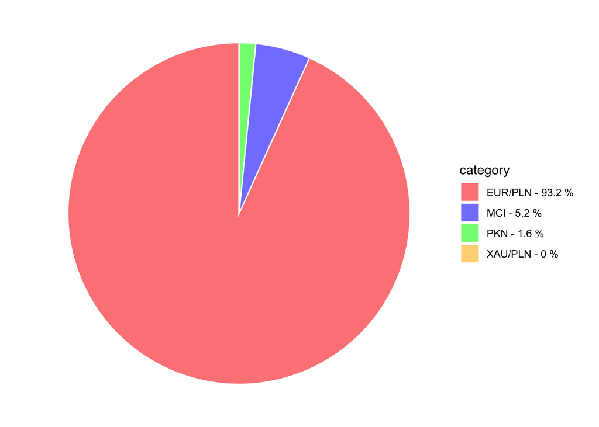

# 5 Portfel z maksymalną efektywnością

Wynika z tego, że portfel całkowicie koncentruje się na jednym aktywie - **Złoto - XAU/PLN** . Średni zwrot portfela wynosi około **0.0013 (0.13%)**. Ryzyko (Odchylenie Standardowe) wynosi około **0.0099 (0.99%)**, co czyni ten portfel relatywnie niskoryzykownym. Wskaźnik Sharpe’a wynosi około **0.1312**, co wskazuje na umiarkowaną efektywność tego portfela w stosunku do poziomu ryzyka. Wybór tego portfela oznacza maksymalizację wskaźnika Sharpe’a, co może być odpowiednie dla inwestorów poszukujących równowagi pomiędzy zwrotem a ryzykiem przy minimalnym zaangażowaniu w bardziej ryzykowne aktywa.

Zalety tego portfela: - **Niskie ryzyko:** Całkowita koncentracja na złocie, które w analizach historycznych cechuje się niską zmiennością. - **Prostota:** Brak dywersyfikacji oznacza brak potrzeby zarządzania wieloma aktywami.

Wady Tego Portfela - **Brak dywersyfikacji:** Portfel jest całkowicie uzależniony od wyników złota, co zwiększa ryzyko systematyczne (specyficzne dla tego rynku). - **Potencjalnie niższy zwrot:** Skoncentrowanie na jednym aktywie o niskiej zmienności może ograniczać możliwości uzyskania wyższych zysków

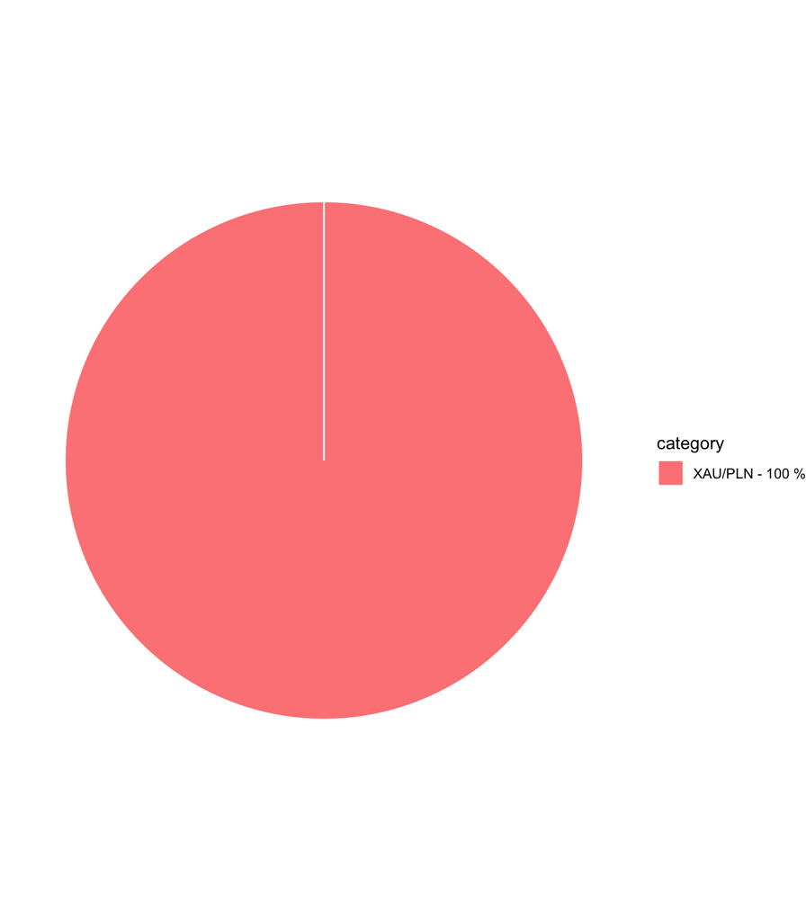

# 6 Wartość współczynników korelacji dla analizowanych inwestycji

**Korelacja** to miara statystyczna, która pokazuje, w jakim stopniu dwie zmienne są ze sobą powiązane. Wartość korelacji wskazuje na siłę i kierunek zależności między zmiennymi:

- **Korelacja dodatnia (pozytywna)**: Kiedy jedna zmienna rośnie, druga również rośnie.
- **Korelacja ujemna (negatywna)**: Kiedy jedna zmienna rośnie, druga maleje.
- **Brak korelacji**: Brak jakiejkolwiek zależności między zmiennymi.

Wartość korelacji mieści się w zakresie od **-1 do 1**: - **1**: Perfekcyjna dodatnia korelacja — zmienne poruszają się w tej samej fazie. - **-1**: Perfekcyjna ujemna korelacja — zmienne poruszają się w przeciwnych kierunkach. - **0**: Brak korelacji — zmienne są niezależne.

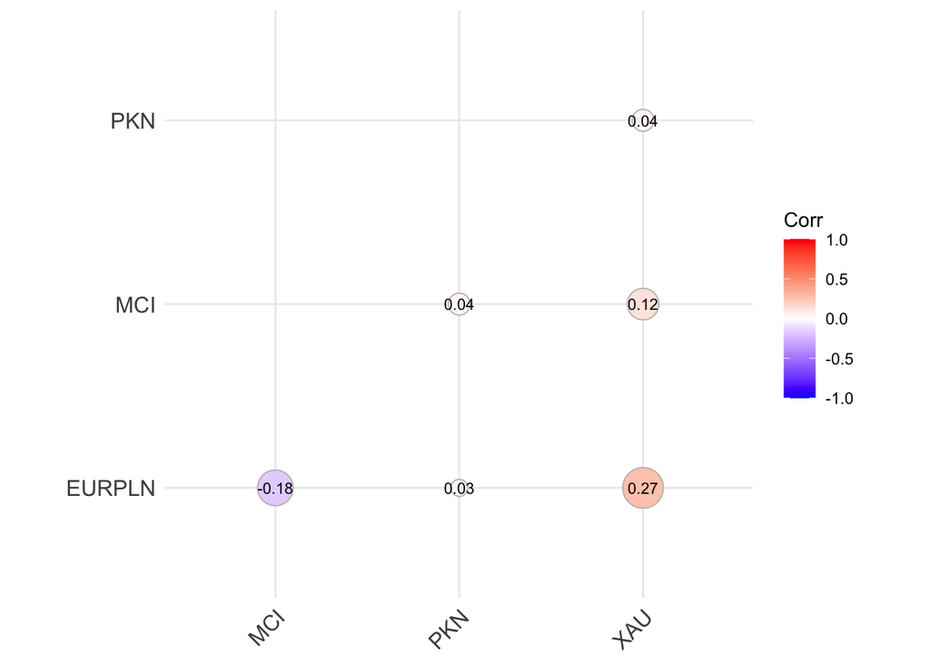

1. **Korelacja między EURPLN a innymi zmiennymi:**
   - **EURPLN ↔︎ MCI**: Współczynnik korelacji wynosi -0.183, co wskazuje na **słabą ujemną korelację** między tymi dwiema zmiennymi. Oznacza to, że wzrost wartości EURPLN jest lekko związany ze spadkiem wartości MCI.
   - **EURPLN ↔︎ PKN**: Korelacja wynosi 0.029, co oznacza, że **brak jest istotnej korelacji** pomiędzy tymi zmiennymi.
   - **EURPLN ↔︎ XAU**: Korelacja wynosi 0.270, co wskazuje na **słabą dodatnią korelację**. Wzrost wartości EURPLN jest nieznacznie powiązany z wzrostem wartości XAU.
2. **Korelacja między MCI a innymi zmiennymi:**
   - **MCI ↔︎ PKN**: Korelacja wynosi 0.038, co oznacza, że istnieje **bardzo słaba dodatnia korelacja** między tymi zmiennymi, praktycznie brak zauważalnej zależności.
   - **MCI ↔︎ XAU**: Współczynnik korelacji wynosi 0.115, co sugeruje **słabą dodatnią korelację** między MCI a XAU, choć nie jest to znacząca zależność.
3. **Korelacja między PKN a XAU:**
   - **PKN ↔︎ XAU**: Korelacja wynosi 0.037, co wskazuje na **bardzo słabą dodatnią korelację** pomiędzy tymi dwiema zmiennymi. Zmiany w wartości PKN mają minimalny wpływ na zmiany w wartości XAU.
4. **Najsilniejsza korelacja** to korelacja między EURPLN a XAU, która wynosi 0.270, wskazując na niewielką, ale zauważalną dodatnią zależność.
   - Wartości korelacji między pozostałymi parami zmiennych są słabe lub praktycznie zerowe, co oznacza, że zmienne te nie wykazują silnych powiązań ze sobą.

# 7 Wskaźniki efektywności

| Metric | Gold | Orlen | Fund | Euro |
| --- | --- | --- | --- | --- |
| Annualized Sharpe Ratio (Rf=4%) | 1.447 | -2.378 | -0.333 | -2.760 |
| Sortino Ratio (MAR=4%) | 0.232 | -0.091 | -0.100 | -0.144 |
| Calmar Ratio | -0.998 | -0.925 | -0.424 | -0.708 |

# 8 Zbiór możliwości inwestycyjnych

Przedstawia wszystkie możliwości kombinacji portfela inwestycyjnego z poszczególnych ryzykownych aktywów. Na wykresie widoczna jest oś X, na której znajduje się ryzyko oraz oczekiwaną stopę zwrotu na osi Y. Postać graficzna pozwala na identyfikację optymalnych portfeli, w tym między innymi portfela o minimalnym ryzyku oraz portfela o maksymalnej efektywności. Niebieski obszar reprezentuje wszystkie możliwości kombinacji portfeli utworzonych z dostępnych aktywów ryzykownych, każdy zaznaczony punkt odpowiada innemu portfelowi. Zielony punkt wskazuje na portfel minimalnego ryzyka, o najniższym poziomie odchylenia standardowego w całym dostępnym zbiorze. Czerwona kropka przedstawia portfel o maksymalnej efektywności, który oferuje najwyższą oczekiwaną stopę zwrotu w stosunku do ryzyka. Czarne punkty na wykresie oznaczają portfele jednoelementowe, które składają się w 100% z jednego poszczególnego aktywa. Dodatkowo na wykresie znajduje się fioletowa krzywa, która reprezentuje granicę efektywną, czyli zbiór portfeli, które są optymalne i oferują najwyższą oczekiwaną stopę zwrotu dla określonego poziomu ryzyka.

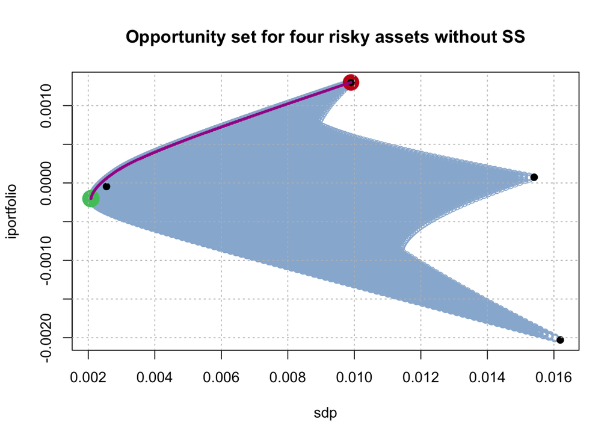

# 9 Portfel o maksymalnym zysku z uwzględnieniem sprzedaży krótkiej

Uzyskanie portfela zapewniającego maksymalny zysk z uwzględnieniem krótkiej sprzedaży daje bardzo ciekawe efekty. Jako że Orlen w całym badanym okresie był w tendencji spadkowej i stracił na wartości akcji ponad 10 złotych, czyli około 20%. Komponując portfel bazując na krótkiej sprzedaży spółki orlen, uzyskujemy w sumie skumulowaną wartość stopy logarytmicznej na poziomie 0.21. Ryzyko tego porfela wyrażone odchyleniem standardowym wynosi 0.016. Współczynnik Sharpe’a wynosił 13.2832, co oznacza, że portfel ten był bardzo efektywny - przyniósł wysokie zyski w stosunku do ryzyka. Oczywiście takie wyniki są bardzo trudne do osiągnięcia w praktyce, ale pokazują, że krótka sprzedaż może być skuteczną strategią inwestycyjną w określonych warunkach rynkowych.

# 10 Zmiany efektywnych portfeli w czasie

1.**Co przedstawia wykres?** Wykres przedstawia, jak **optymalne portfele inwestycyjne zmieniają się w czasie**, analizując zależność między **ryzykiem a stopą zwrotu**.

2.**Elementy wykresu** - **Punkty** 🟣🔴 → Reprezentują optymalne portfele w kolejnych okresach. - Kolor oznacza **moment w czasie**. - **Niebieskie punkty** to wcześniejsze okresy. - **Czerwone punkty** to najnowsze okresy. - **Oś X (Ryzyko portfela [%])** → Mierzy poziom zmienności. - **Oś Y (Stopa zwrotu [%])** → Oczekiwana rentowność. - **Niebieska linia** → Trend zmian portfeli w czasie.

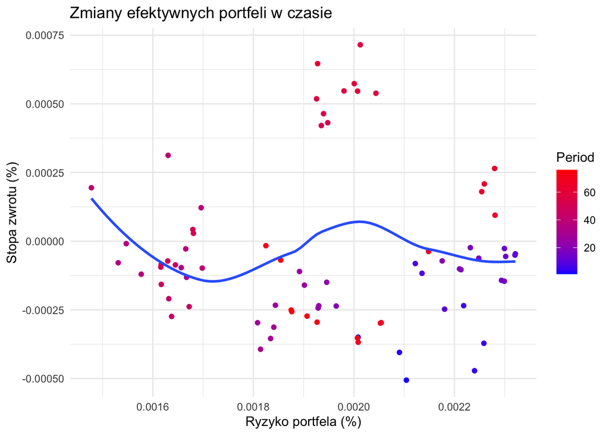

# 11 Skład portfeli z granicy efektywnej

Granica efektywna przedstawia portfele oferujące najlepszy zwrot przy danym ryzyku. Przy niskim ryzyku dominują aktywa defensywne, a przy wyższym wzrasta udział aktywów agresywnych. W środkowej części granicy portfele są najbardziej zdywersyfikowane.

[figure not shown]

Wykres przedstawia skład portfela efektywnego wzdłuż granicy efektywnej. Przy niskim ryzyku dominuje Euro, zapewniając stabilność, a przy wyższym ryzyku rośnie udział złota. W centralnym obszarze portfel jest bardziej zdywersyfikowany, co wskazuje na optymalny balans między ryzykiem a zwrotem.

# 12 Podsumowanie

Analiza dotycząca portfela inwestycyjnego złożonego z czterech aktywów, w tym: złota, euro, funduszu MCI i akcji PKN Orlen, zbadanych w okresie od lipca do listopada 2024 roku pozwoliła ocenić efektywność portfela oraz ryzyko wiążące się z poszczególnych składników. Fundusz MCI i akcje PKN charakteryzują się wysoką zmiennością, co wpływa na podwyższone ryzyko, podczas gdy euro i złoto są bardziej stabilne, co sugeruje niższe ryzyko. W ramach analizy portfela o minimalnym ryzyku najwięcej środków zainwestowano w euro, co zapewniło niski poziom zmienności. Z kolei portfel o maksymalnej efektywności skoncentrował się na złocie, oferując umiarkowaną efektywność w stosunku do ryzyka. Analiza korelacji między aktywami wykazała głównie słabe zależności, a interesującym przypadkiem była strategia krótkiej sprzedaży akcji PKN, która przy wysokim współczynniku Sharpe’a wykazała dużą efektywność w analizowanym okresie. Ważne jest zrozumienie wzajemnych zależności między aktywami oraz świadome podejmowanie decyzji inwestycyjnych, aby uzyskać najlepszy wynik przy optymalnym poziomie ryzyka.

# 13 Bibliografia

1. Urząd Komisji Nadzoru Finansowego. “KNF.” *Knf.gov.pl*, 2024, [www.knf.gov.pl/dla_rynku/procesy_licencyjne/kapitalowy/zarzadzajacy_alternatywnymi_spolkami_inwestycyjnymi_ZASI/pytania_i_odpowiedzi. Accessed 8 Jan. 2025](http://www.knf.gov.pl/dla_rynku/procesy_licencyjne/kapitalowy/zarzadzajacy_alternatywnymi_spolkami_inwestycyjnymi_ZASI/pytania_i_odpowiedzi.%20Accessed%208%20Jan.%202025).
2. “Opportunity Set Definition and Tutorial for Investment Modeling | FactorPad.” *Factorpad.com*, factorpad.com/fin/glossary/opportunity-set.html.
3. “MCI - MCI Capital ASI SA - Stooq.” *Stooq*, 2025, stooq.pl/q/p/?s=mci&fbclid=IwZXh0bgNhZW0CMTEAAR1EYBwR60o75nUTSQ3b-95iZ-nU2zflpBnvTctKiazgGsZhliUjWwLx0n0_aem_Nennkxm8HU8jLqFlHg0vJA. Accessed 8 Jan. 2025.